Measuring Well Productivity by Completion Design

Flaming  
Trevathan  
Nixon  
Friedrich

July 24, 2018

# 1 Executive Summary

FTNF Analytics is a boutique firm specializing in statistics and data analysis for the energy sector. The FTNF team includes experts in geology, data visualization, statistics, and predictive modeling. Our practice services producers globally with a special emphasis on those operating in the Southwest United States.

The Consortium of Texas Oil Producers (CTOP), has engaged FTNF to develop a study to better understand the potential for production in designated areas and help decide the best way to allocate their valuable resources. Specifically, CTOP needs a way to predict potential energy production (and revenues generated).

FTNF is the ideal partner for this undertaking. Our process includes enriching existing CTOP data to improve the ability to predict production outcomes. We start with exploring the data, creating new data, and augmenting the data. Once satisfied, we proceed to analyzing the data using contemporary statistical methods. From there, we build predictive models to provide insight necessary to make drilling decisions.

CTOP companies no longer have to rely on hope as a strategy for finding productive wells. With the help of FTNF Analytics, you can rely on sound science and quantifiable predictions.

# 2 Frac Focus Data Source

The Hydraulic Fracturing Disclosure and Education websites found [here](http://fracfocusdata.org) are being hosted by the Ground Water Protection Council (GWPC) and the Interstate Oil and Gas Compact Commission (IOGCC). This website provides a central location for public and industry to communicate and relay information on the chemicals used during the process of hydraulic fracturing of oil or gas wells. The FracFocus website provides impartial and balanced education tools to the public on the topic of hydraulic fracturing.

The GWPC and IOGCC are uniquely suited to host these websites due to their impartial nature and ties to the regulated and regulatory community. This website provides a means for industry to voluntarily supply hydraulic fracturng chemical data in a consistent and centralized location. This open process assists both public and industry by supplying a centralized repository for the data and removing similar fragmented efforts from around the web.

These websites provide the following: A means to Search for voluntarily submitted chemical records by State/County, Operator and Well. An Education and Informative site for the public and industry on Hydraulic Fracturing Chemicals and the processes used in Hydraulic Fracturing of wells.

The data related to chemicals used to enrich the data on wells comes from the chemical registry website FracFocus.com. The FracFocus website and data is maintained by two organizations: Interstate Oil and Gas Compact Commission and the Ground Water Protection Council.

The site maintains data on over 127,000 wells and includes not only data about which chemicals are used, but also data about groundwater protection. FracFocus has instituted a Help Desk to address any issues you may have in using the system. You can reach the Help Desk Monday-Thursday from 8 AM to 5 PM and on Friday from 8 AM to 4 PM CDT at 405-607-6808.

## 2.1 FracFocus Dataset Import

- 19 of the 24 variables are selected for the study The deata from FracFocus is obtained via an API call. For the sake of reproducibility, the API call is made outside of the code and the resulting CSV is stored in the program repository.

```r
#import fracfocus data
fracfocus <- read.csv("../data/fracfocus_registry.csv") %>%
              standardize_names() %>%
              rename(api14='apinumber') %>%
              mutate( api14=as.character(api14)
                     ,api10 = as.character(api10)
                     ,tvd = as.integer(tvd)
                     ,jobstartdate = as.Date(jobstartdate, "%m/%d/%Y")
                     ,jobenddate = as.Date(jobenddate, "%m/%d/%Y")
                     ,jobduration = jobenddate - jobstartdate
                     ,totalbasewatervolume = as.double(totalbasewatervolume)
                     ,totalbasenonwatervolume = as.double(totalbasenonwatervolume)
                     ,percenthighadditive = as.double(percenthighadditive)
                     ,percenthfjob = as.double(percenthfjob)
                     ,massingredient = as.double(massingredient)
                     ,iswater = as.logical.factor(iswater)
                     ) %>%
              select( api14
                     ,api10
                     ,wellname
                     ,operatorname
                     ,tvd
                     ,jobstartdate
                     ,jobenddate
                     ,jobduration
                     ,latitude
                     ,longitude
                     ,totalbasewatervolume
                     ,totalbasenonwatervolume
                     ,statename
                     ,countyname
                     ,ingredientname
                     ,percenthighadditive
                     ,percenthfjob
                     ,massingredient
                     ,iswater
                     ) %>%
             as.tibble()
```

## 2.2 Locations and Wellbores

- The FracFocus Data consists of Well Data for 3162 locations with 3163 wellbores

```r
# count unique wellbores. api14 represents a unique wellbore.
ff_wellcount <- fracfocus %>%
    select(api14) %>%
    distinct(api14) %>%
    summarize(wellbores = n())

# count unique locations. api10 represents a unique XY coordinate pair.
ff_loccount <- fracfocus %>%
    select(api10) %>%
    distinct(api10) %>%
    summarize(locations = n())

kable(data.frame("Distinct Locations" = ff_loccount
                ,"Unique Wellbores" = ff_wellcount
                ,row.names=c("Frac_Focus"))
        , digits = 0) %>%
    kable_styling(position = "center"
                 ,full_width = FALSE
                 )
```

|  | locations | wellbores |
| --- | --- | --- |
| Frac_Focus | 3162 | 3163 |

## 2.3 Proppant and Water

- Filtering and grouping of aggregates proppants and water for each wellbore

```r
# create a tidy table summarizing the data imported from the FracFocus registry
ff_summary <- fracfocus %>%
    filter('sand' %in% ingredientname
        | 'silica' %in% ingredientname
        | 'propp' %in% ingredientname
        | 'mesh' %in% ingredientname
        | 'brown' %in% ingredientname
        | 'white' %in% ingredientname
        | '30%50' %in% ingredientname
        | '40%70' %in% ingredientname
        | '30%50' %in% ingredientname
        | '100' %in% ingredientname
        ) %>%
    group_by(api10) %>%
    summarize(totalwater.gal = max(totalbasewatervolume)
              ,totalwater.bbl = totalwater.gal/42
              ,totalsand.lb = sum(massingredient)
              ,tvd.ft = max(tvd)
              ,jobduration.day = max(jobduration)
              ) %>%
    inner_join(
                fracfocus %>%
                    group_by(api10) %>%
                    summarize(additive.ct = n_distinct(ingredientname))
                ,by = c("api10", "api10")
              )
```

## 2.4 Aggregates

- A table of FracFocus wellbore specific descriptive statistics

```r
# generate descriptive statistics for the summarized chemical data
kable(descr(ff_summary), digits = 0) %>%
    kable_styling(position = "center"
                 ,full_width = FALSE
                 )
```

|  | Mean | Std.Dev | Min | Median | Max | Q1 | Q3 | N.Valid |
| --- | --- | --- | --- | --- | --- | --- | --- | --- |
| totalwater.gal | 8631322 | 8517091 | 0 | 7960218 | 202222958 | 1348074 | 13285482 | 3162 |
| totalwater.bbl | 205508 | 202788 | 0 | 189529 | 4814832 | 32097 | 316321 | 3162 |
| totalsand.lb | 834510 | 520151 | 1 | 807304 | 4556769 | 556858 | 1117587 | 3162 |
| tvd.ft | 88518 | 4445993 | 0 | 9281 | 250014549 | 8011 | 10575 | 3162 |
| additive.ct | 32 | 13 | 1 | 30 | 86 | 21 | 42 | 3162 |

# 3 Driftwood Well Data Source

The Driftwood dataset was provided by the client and can be found [here](https://github.com/la-mar/DDS_Case_Study_2/blob/master/data/deo_well_data.csv). This dataset provides a central location for wellsites to communicate and relay information on the drilling parameters used during the process of extraction of oil or gas wells. The following variables are included within the dataset:

- API - fourteen digit american petroleum institue number
- API10 - ten digit american petroleum institue number. Represents a unique hole in the ground.
- oper_alias - standardized operator (company) names
- Form_Avg - geological formation names
- PerfLL - wellbore lateral length
- FirstProd - date of first oil/gas production
- Oil_PkNorm_PerK_6mo - peak oil production within the first 6 months of first production, normalized to 1000 ft

## 3.1 Well Features Import

- 7 of the 8 variables are selected for the study

```r
# import data features of individual wells
wellfeatures <- read.csv("../data/deo_well_data.csv") %>%
             standardize_names() %>%
             rename(oil.pk.bbl='oilpknormperk6mo'
                    ,api14='api'
                    ,perfll.ft='perfll') %>%
             mutate(api14 = as.character(api14)
                   ,api10 = as.character(api10)
                   ,perfll.ft=as.integer(perfll.ft)
                   ,firstprod = as.Date(firstprod, "%m/%d/%Y")
                   ,oil.pk.bbl = as.integer(oil.pk.bbl)
                   ,vintage.yr = as.integer(format(firstprod, '%Y'))
                   ,age.mo = as.integer((as.Date('08/01/2018', "%m/%d/%Y") - firstprod)/(365/12)) #30.4 = avg month duration
                ) %>%
             as.tibble()
```

## 3.2 Locations and Wellbores

- The Well Features and Characteristics consists of Well Data for 2907 locations with 2914 wellbores

```r
# count unique wellbores. api14 represents a unique wellbore.
wf_wellcount <- wellfeatures %>%
    select(api14) %>%
    distinct(api14) %>%
    summarize(wellbores = n())

# count unique locations. api10 represents a unique XY coordinate pair.
wf_loccount <- wellfeatures %>%
    select(api10) %>%
    distinct(api10) %>%
    summarize(locations = n())

kable(data.frame("Distinct Locations" = wf_loccount
                ,"Unique Wellbores" = wf_wellcount
                ,row.names=c("Well_Features")
                )
          , digits = 0) %>%
        kable_styling(position = "center",
                full_width = FALSE,
                bootstrap_options = c("striped", "hover", "condensed")
                )
```

|  | locations | wellbores |
| --- | --- | --- |
| Well_Features | 2907 | 2914 |

## 3.3 Aggregates

```r
# generate descriptive statistics for the summarized chemical data
kable(descr(ff_summary), digits = 0) %>%
    kable_styling(position = "center"
                 ,full_width = FALSE
                 )
```

|  | Mean | Std.Dev | Min | Median | Max | Q1 | Q3 | N.Valid |
| --- | --- | --- | --- | --- | --- | --- | --- | --- |
| totalwater.gal | 8631322 | 8517091 | 0 | 7960218 | 202222958 | 1348074 | 13285482 | 3162 |
| totalwater.bbl | 205508 | 202788 | 0 | 189529 | 4814832 | 32097 | 316321 | 3162 |
| totalsand.lb | 834510 | 520151 | 1 | 807304 | 4556769 | 556858 | 1117587 | 3162 |
| tvd.ft | 88518 | 4445993 | 0 | 9281 | 250014549 | 8011 | 10575 | 3162 |
| additive.ct | 32 | 13 | 1 | 30 | 86 | 21 | 42 | 3162 |

# 4 Data Exploration

Here the FracFocus and Well Features and Characteristics datasets are joined into a new dataset named welldata by the common variable api10, which represents a specific wellbore hole.

## 4.1 Calculations

- Columns are created by the mutate function to provide 8 new variables for upcomming data analysis

```r
# create new table by joining data on wells with data on chemicals
welldata <- wellfeatures %>%
    inner_join(ff_summary, by = c("api10", "api10")) %>%
    #rename(vintage.yr = vintage) %>%
    mutate(lb.ft = totalsand.lb / perfll.ft
           , gal.ft = totalwater.gal / perfll.ft #todo: totalwater bbl looks way too high.
           , bbl.ft = gal.ft / 42
           , distance = sqrt(gal.ft ^ 2 + lb.ft ^ 2) * (180 / pi) # linear_distance_from_origin (hypotenuse length)
           , angle = atan(gal.ft / lb.ft) * (180 / pi) #in degrees
           , deviation = abs(45 - angle) #deviation_from_45deg
           , weight = 500 # weighting_constant
           , frac.size = distance-(deviation-weight) # weighted_distance_from_origin
           ,log.oil.pk.bbl = log(oil.pk.bbl)
           ,log.frac.size = log(frac.size)
           ,log.bbl.ft = log(bbl.ft)
           ,log.lb.ft = log(lb.ft)
           ) %>%
           select(-distance, -angle, -deviation, -weight)
```

```r
# function call to provide summary statistics for well data
    kable(descr(welldata), digits = 0) %>%
    kable_styling(position = "center"
                 ,full_width = TRUE)
```

|  | Mean | Std.Dev | Min | Median | Max | Q1 | Q3 | N.Valid |
| --- | --- | --- | --- | --- | --- | --- | --- | --- |
| perfll.ft | 868 | 491 | 1 | 909 | 1570 | 524 | 1288 | 1908 |
| oil.pk.bbl | 1071 | 601 | 1 | 1104 | 1854 | 541 | 1650 | 1908 |
| vintage.yr | 2015 | 2 | 2001 | 2015 | 2018 | 2014 | 2016 | 1742 |
| age.mo | 35 | 18 | 5 | 37 | 209 | 19 | 47 | 1742 |
| totalwater.gal | 13387410 | 7837647 | 0 | 11351928 | 202222958 | 8640555 | 17433362 | 1908 |
| totalwater.bbl | 318748 | 186611 | 0 | 270284 | 4814832 | 205728 | 415080 | 1908 |
| totalsand.lb | 774981 | 529758 | 7 | 763048 | 4496574 | 488646 | 1065444 | 1908 |
| tvd.ft | 8895 | 3183 | 0 | 8649 | 92089 | 7758 | 9426 | 1908 |
| additive.ct | 33 | 13 | 5 | 31 | 86 | 23 | 44 | 1908 |
| lb.ft | 39384 | 204467 | 0 | 871 | 2292880 | 433 | 1765 | 1908 |
| gal.ft | 803290 | 5707366 | 0 | 12953 | 202222958 | 9761 | 17991 | 1908 |
| bbl.ft | 19126 | 135890 | 0 | 308 | 4814832 | 232 | 428 | 1908 |
| frac.size | 46224719 | 327197476 | 23658 | 747575 | 11586664381 | 563766 | 1035822 | 1908 |
| log.oil.pk.bbl | 7 | 1 | 0 | 7 | 8 | 6 | 7 | 1908 |
| log.frac.size | 14 | 2 | 10 | 14 | 23 | 13 | 14 | 1908 |
| log.bbl.ft | -Inf | NaN | -Inf | 6 | 15 | 5 | 6 | 1908 |
| log.lb.ft | 6 | 4 | -5 | 7 | 15 | 6 | 7 | 1908 |

## 4.2 Munge Datasets

- Here the welldata is cleaned in preparation for statistical procedures and visualization
  - Before developing models and making predictions, it’s important to understand the data.
  - Here we’re summarize the data mathematically and explore it visually.

```r
# create a count of well observations
wd_nrow <- list()
wd_nrow[['All Records']] <- nrow(welldata)
```

```r
# remove observations with insufficient information
welldata <- welldata %<>%
                filter(!formavg %in% c("UNKNOWN","GRID_ERROR"))
```

```r
# provide count of observations that will be used for analysis
wd_nrow[['Cleaned Forms']] <- nrow(welldata)
```

```r
# summarizes the number of "clean" observations
wd_nrow[['Cleaned Frac Size']] <- nrow(welldata)
```

```r
# summarizes the number of observations after
# removing NAs from vintage column
welldata <- welldata %>% na.omit(vintage.yr)

wd_nrow[['Cleaned Vintage']] <- nrow(welldata)
# wd_nrow %>% as.data.frame()
```

```r
 kable(wd_nrow %>% as.data.frame()) %>%
    kable_styling(position = "center"
                 ,full_width = TRUE) %>%
 add_header_above(c(" ", "Cleansed" = 3))
```

| All.Records | Cleansed Cleaned.Forms | Cleansed Cleaned.Frac.Size | Cleansed Cleaned.Vintage |
| --- | --- | --- | --- |
| 1908 | 1856 | 1856 | 1715 |

## 4.3 Summarize Well Data

- A table of Well Data wellbore specific descriptive statistics

```r
# function call to provide summary statistics for well data
    kable(descr(welldata), digits = 0) %>%
    kable_styling(position = "center"
                 ,full_width = TRUE)
```

|  | Mean | Std.Dev | Min | Median | Max | Q1 | Q3 | N.Valid |
| --- | --- | --- | --- | --- | --- | --- | --- | --- |
| perfll.ft | 844 | 458 | 1 | 895 | 1570 | 530 | 1216 | 1715 |
| oil.pk.bbl | 997 | 576 | 1 | 1022 | 1854 | 487 | 1508 | 1715 |
| vintage.yr | 2015 | 1 | 2001 | 2015 | 2018 | 2014 | 2016 | 1715 |
| age.mo | 34 | 17 | 5 | 37 | 209 | 19 | 47 | 1715 |
| totalwater.gal | 13030462 | 7697296 | 0 | 11018196 | 202222958 | 8543724 | 16540356 | 1715 |
| totalwater.bbl | 310249 | 183269 | 0 | 262338 | 4814832 | 203422 | 393818 | 1715 |
| totalsand.lb | 781277 | 536322 | 7 | 776275 | 4496574 | 487398 | 1082611 | 1715 |
| tvd.ft | 8971 | 3276 | 0 | 8669 | 92089 | 7800 | 9426 | 1715 |
| additive.ct | 33 | 13 | 5 | 31 | 86 | 23 | 44 | 1715 |
| lb.ft | 25528 | 167913 | 0 | 910 | 2143603 | 448 | 1766 | 1715 |
| gal.ft | 494862 | 5401735 | 0 | 12905 | 202222958 | 9737 | 17851 | 1715 |
| bbl.ft | 11782 | 128613 | 0 | 307 | 4814832 | 232 | 425 | 1715 |
| frac.size | 28541135 | 309632332 | 23658 | 745429 | 11586664381 | 560992 | 1025937 | 1715 |
| log.oil.pk.bbl | 7 | 1 | 0 | 7 | 8 | 6 | 7 | 1715 |
| log.frac.size | 14 | 2 | 10 | 14 | 23 | 13 | 14 | 1715 |
| log.bbl.ft | -Inf | NaN | -Inf | 6 | 15 | 5 | 6 | 1715 |
| log.lb.ft | 6 | 4 | -5 | 7 | 15 | 6 | 7 | 1715 |

## 4.4 Completion Variance

- A visualization of the summary statistics for Well Data

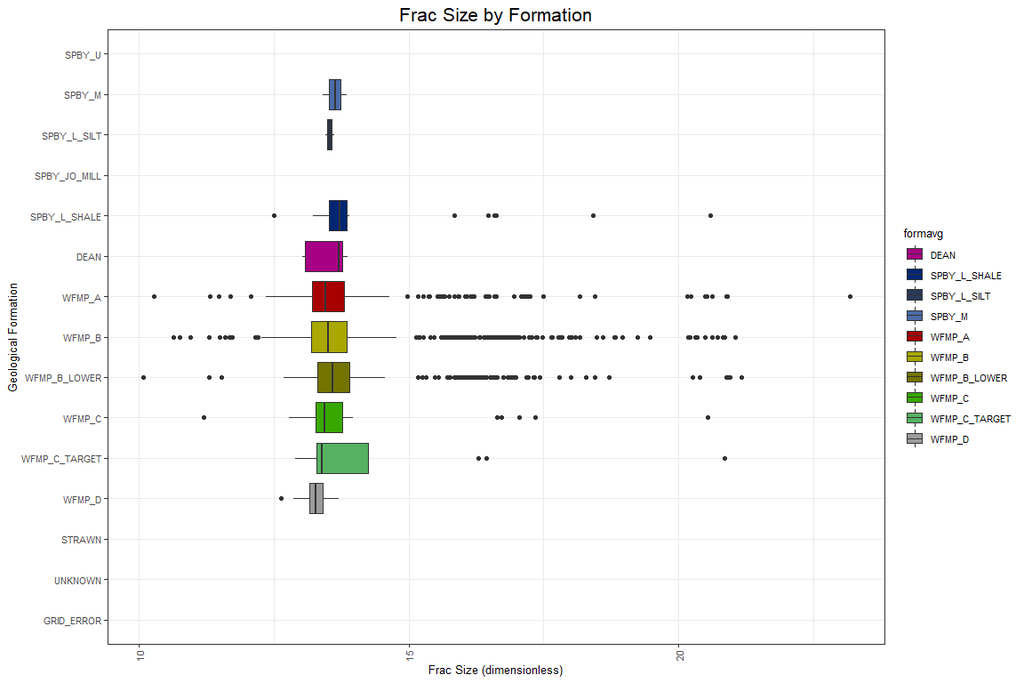

```r
# create a summary boxplot of wells by size
ggplot((welldata), #%>% na.omit(abv)),
       aes(x=reorder(formavg, tvd.ft, FUN=mean) , y=log(frac.size), fill = formavg)) +
  geom_boxplot() +
  scale_fill_manual(values = COL.ALLFORMS) +
  scale_x_discrete(limits = rev(names(COL.ALLFORMS))) + #manually set x.axis order
  ggtitle("Frac Size by Formation") +
  xlab("Geological Formation") +
  ylab("Frac Size (dimensionless)") +
  coord_flip() +
  theme(text = element_text(size=10),
        axis.text.x = element_text(angle=90, vjust=0.5),
        plot.title = element_text(hjust = 0.5, size = 16))
```

[figure not shown]

```r
# create a summary boxplot of wells by peak production
ggplot((welldata), #%>% na.omit(abv)),
       aes(x=formavg , y=oil.pk.bbl, fill = formavg)) +
  geom_boxplot() +
  scale_fill_manual(values = COL.ALLFORMS) +
  scale_x_discrete(limits = rev(names(COL.ALLFORMS))) + #manually set x.axis order
  ggtitle("Frac Size by Formation") +
  xlab("Geological Formation") +
  ylab("International Bitterness Units (IBU)") +
  coord_flip() +
  theme(text = element_text(size=10),
        axis.text.x = element_text(angle=90, vjust=0.5),
        plot.title = element_text(hjust = 0.5, size = 16))
```

## 4.5 Wellbore Status Frequencies

- A table of well frequency by respective year

```r
# calculate frequency of wells by year
kable(freq(welldata$vintage.yr), digits = 0) %>%
    kable_styling(position = "left",
                  full_width = FALSE
                 )
```

|  | Freq | % Valid | % Valid Cum. | % Total | % Total Cum. |
| --- | --- | --- | --- | --- | --- |
| 2001 | 2 | 0 | 0 | 0 | 0 |
| 2011 | 1 | 0 | 0 | 0 | 0 |
| 2012 | 16 | 1 | 1 | 1 | 1 |
| 2013 | 139 | 8 | 9 | 8 | 9 |
| 2014 | 443 | 26 | 35 | 26 | 35 |
| 2015 | 403 | 23 | 59 | 23 | 59 |
| 2016 | 286 | 17 | 75 | 17 | 75 |
| 2017 | 374 | 22 | 97 | 22 | 97 |
| 2018 | 51 | 3 | 100 | 3 | 100 |
| <NA> | 0 | NA | NA | 0 | 100 |
| Total | 1715 | 100 | 100 | 100 | 100 |

## 4.6 Productivity Frequencies

```r
# calculate frequency of wells by status
kable(freq(welldata$status), digits = 0) %>%
    kable_styling(position = "right",
                 full_width = FALSE
                 )
```

|  | Freq | % Valid | % Valid Cum. | % Total | % Total Cum. |
| --- | --- | --- | --- | --- | --- |
| COMPLETED | 0 | 0 | 0 | 0 | 0 |
| DUC | 0 | 0 | 0 | 0 | 0 |
| PERMIT | 0 | 0 | 0 | 0 | 0 |
| PRODUCING | 1705 | 99 | 99 | 99 | 99 |
| STALE-PERMIT | 0 | 0 | 99 | 0 | 99 |
| TA | 10 | 1 | 100 | 1 | 100 |
| <NA> | 0 | NA | NA | 0 | 100 |
| Total | 1715 | 100 | 100 | 100 | 100 |

```r
# calculate frequency of wells by status
kable(freq(welldata$status), digits = 0) %>%
    kable_styling(position = "right",
                 full_width = FALSE
                 )
```

|  | Freq | % Valid | % Valid Cum. | % Total | % Total Cum. |
| --- | --- | --- | --- | --- | --- |
| COMPLETED | 0 | 0 | 0 | 0 | 0 |
| DUC | 0 | 0 | 0 | 0 | 0 |
| PERMIT | 0 | 0 | 0 | 0 | 0 |
| PRODUCING | 1705 | 99 | 99 | 99 | 99 |
| STALE-PERMIT | 0 | 0 | 99 | 0 | 99 |
| TA | 10 | 1 | 100 | 1 | 100 |
| <NA> | 0 | NA | NA | 0 | 100 |
| Total | 1715 | 100 | 100 | 100 | 100 |

### 4.7.1 Frac Size

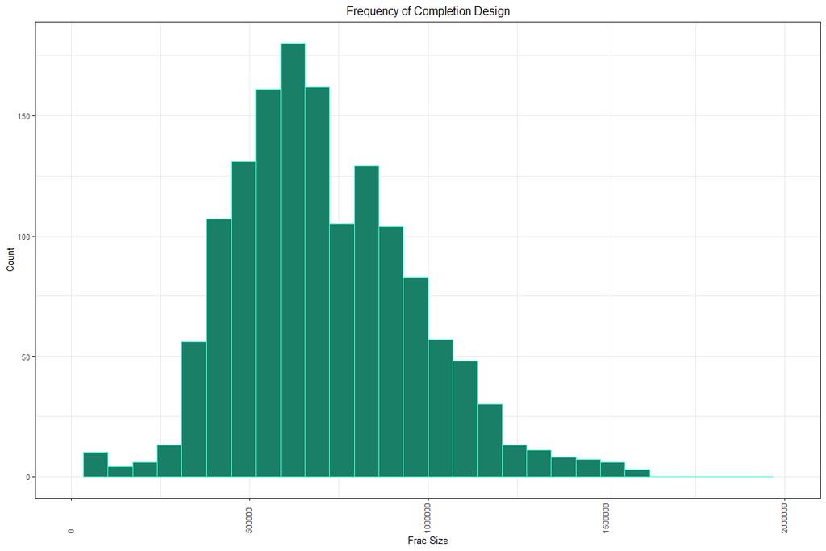

```r
ggplot(welldata, aes(x = frac.size, fill = vintage.yr)) +
        geom_histogram(
            fill = COL.M.G1,
           color = COL.M.G3) +
        xlim(0, 2000000) +
  theme(text = element_text(size=10),
        axis.text.x = element_text(angle=90, hjust=0, vjust = .3))  +
  theme(legend.position="none") +
  ggtitle("Frequency of Completion Design") +
  xlab("Frac Size") +
  ylab("Count") +
  theme(plot.title = element_text(hjust = 0.5))
```

### 4.7.2 Oil Productivity

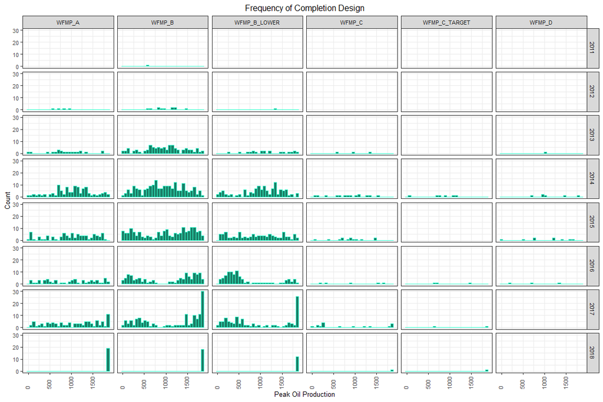

```r
ggplot(welldata %>%
        filter(vintage.yr >= 2011 & formavg %in% WFMP_FORMS)
      , aes(x = oil.pk.bbl, fill = formavg)) +
        geom_histogram(
            fill = COL.M.G1,
           color = COL.M.G3, ) +
        #geom_freqpoly() +
        #xlim(0, 2000000) +
  theme(text = element_text(size=10),
        axis.text.x = element_text(angle=90, hjust=0, vjust = .3))  +
  theme(legend.position="none") +
  ggtitle("Frequency of Completion Design") +
  xlab("Peak Oil Production") +
  ylab("Count") +
  theme(plot.title = element_text(hjust = 0.5)) +
  facet_grid(vintage.yr ~ formavg)
```

### 4.7.3 Boxplots

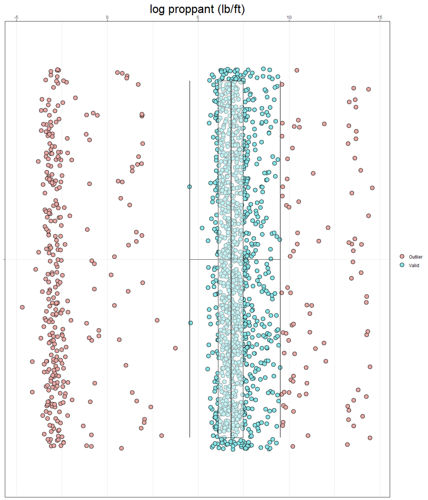

```r
p.var ='log.lb.ft'

p.outliers <- boxplot(welldata %>% select(p.var), plot = FALSE)[["out"]]


ggplot((welldata %>% drop_na(log.lb.ft)), aes(x="", y=log.lb.ft)) +
      geom_point(aes(fill = ifelse((log.lb.ft %in% p.outliers),"Outlier","Valid")),
                 size = 4,
                 shape = 21,
                 position = position_jitter())+
      stat_boxplot(geom ='errorbar') +
      geom_boxplot(alpha=.5,
                   outlier.shape = NA) +
      guides(fill=guide_legend(title= NULL)) +
      xlab(NULL) +
      ylab("log proppant (lb/ft)") +
      scale_y_continuous(position = "right") + #,
                         #breaks = c(.025, .05, .075, .1, .125),
                         #limits = c(0.025, .125)) +
      scale_fill_manual(values = c(COL.A.R, COL.A.B)) +
      theme(plot.title = element_text(hjust = 0.5, size = 22),
            axis.title.y=element_blank(),
            axis.title.x=element_text(size = 24)) +
      coord_flip()
```

[figure not shown]

```r
p.var ='log.bbl.ft'


p.outliers <- boxplot(welldata %>% select(p.var), plot = FALSE)[["out"]]


ggplot((welldata %>% drop_na(log.bbl.ft)), aes(x="", y=log.bbl.ft)) +
      geom_point(aes(fill = ifelse((log.bbl.ft %in% p.outliers),"Outlier","Valid")),
                 size = 4,
                 shape = 21,
                 position = position_jitter())+
      stat_boxplot(geom ='errorbar') +
      geom_boxplot(alpha=.5,
                   outlier.shape = NA) +
      guides(fill=guide_legend(title= NULL)) +
      xlab(NULL) +
      ylab("log proppant (bbl/ft)") +
      scale_y_continuous(position = "right") + #,
                         #breaks = c(.025, .05, .075, .1, .125),
                         #limits = c(0.025, .125)) +
      scale_fill_manual(values = c(COL.A.R, COL.A.G)) +
      theme(plot.title = element_text(hjust = 0.5, size = 22),
            axis.title.y=element_blank(),
            axis.title.x=element_text(size = 24)) +
      coord_flip()
```

## 4.8 Multiple Linear Regression

- Multiple Linear Regression Model for Well Productivity given Aggregate and Formation Interaction

- formula = lm(log(oil.pk.bbl) ~ log(frac.size) : formavg, data=welldata)

The formula is typically written as Y ~ X1 + X2 + … + Xk where the ~ separates the response variable log(oil.pk.bbl) on the left from the predictor variables log(frac.size) : formavg on the right, and the predictor variables are separated by + signs. The colon is used to denote an interaction between predictor variables. A prediction of y from x, z, and the interaction between x and z would be coded y ~ x + z + x:z.

```r
# Linear Regression Model for Well Productivity
well.production <- lm(log.oil.pk.bbl ~ log.frac.size : formavg, data = welldata)
```

```r
# Linear Regression Model for Well Productivity Summary}
summary(well.production)
```

```
##
## Call:
## lm(formula = log.oil.pk.bbl ~ log.frac.size:formavg, data = welldata)
##
## Residuals:
##     Min      1Q  Median      3Q     Max
## -6.5388 -0.3630  0.3245  0.6889  1.5302
##
## Coefficients:
##                                    Estimate Std. Error t value             Pr(>|t|)
## (Intercept)                         5.59209    0.22439  24.921 < 0.0000000000000002 ***
## log.frac.size:formavgDEAN           0.05920    0.03716   1.593             0.111285
## log.frac.size:formavgSPBY_L_SHALE   0.02542    0.01979   1.285             0.199139
## log.frac.size:formavgSPBY_L_SILT    0.02856    0.05494   0.520             0.603177
## log.frac.size:formavgSPBY_M         0.10701    0.05455   1.962             0.049945 *
## log.frac.size:formavgSTRAWN+        0.02256    0.03764   0.599             0.549076
## log.frac.size:formavgWFMP_A         0.08151    0.01627   5.009          0.000000603 ***
## log.frac.size:formavgWFMP_B         0.07298    0.01606   4.545          0.000005892 ***
## log.frac.size:formavgWFMP_B_LOWER   0.06439    0.01622   3.969          0.000075194 ***
## log.frac.size:formavgWFMP_C         0.06286    0.01885   3.334             0.000873 ***
## log.frac.size:formavgWFMP_C_TARGET  0.07541    0.02494   3.024             0.002534 **
## log.frac.size:formavgWFMP_D         0.08168    0.02421   3.374             0.000758 ***
## ---
## Signif. codes:  0 '***' 0.001 '**' 0.01 '*' 0.05 '.' 0.1 ' ' 1
##
## Residual standard error: 1.002 on 1703 degrees of freedom
## Multiple R-squared:  0.02871,    Adjusted R-squared:  0.02244
## F-statistic: 4.577 on 11 and 1703 DF,  p-value: 0.000000695
```

### 4.8.1 MLR Plots

- Plots of Multiple Linear Regression Model for Production given all Aggregate-Formation Interactions

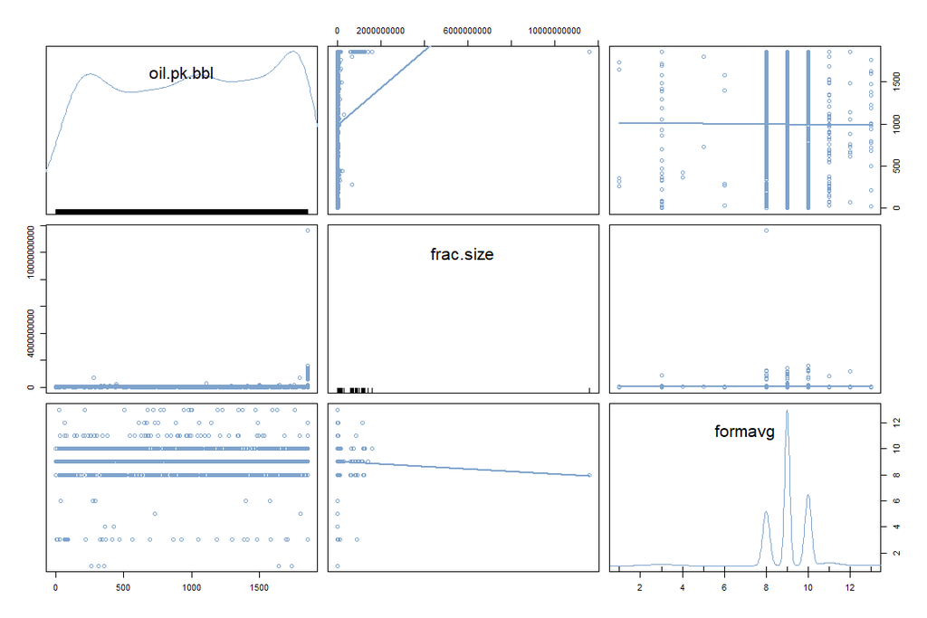

```r
# Linear Regression Model for Well Productivity Plots
scatterplotMatrix(welldata %>% select(oil.pk.bbl, frac.size, formavg)
                  , smooth=FALSE
                  , diagonal="histogram"
                  , col= COL.CP.B1)
```

Unfortunately, fitting the model is only the first step in the analysis. Once you fit a regression model, you need to evaluate whether youâ€™ve met the statistical assumptions underlying your approach before you can have confidence in the inferences you draw. The use of confidence intervals, overdispersion tests, and the anova test will be useful in checking if the statistical assumptions are met.

### 4.8.2 Confidence

- 95% CIs for Significant Aggregate-Formation Combinations

```r
#  Linear Regression Model for Well Productivity 95% CIs}
#95% CI for Linear Regression Model
confint(well.production)
```

```
##                                             2.5 %     97.5 %
## (Intercept)                         5.15197468326 6.03220931
## log.frac.size:formavgDEAN          -0.01367664156 0.13207616
## log.frac.size:formavgSPBY_L_SHALE  -0.01339273299 0.06422537
## log.frac.size:formavgSPBY_L_SILT   -0.07918830395 0.13631620
## log.frac.size:formavgSPBY_M         0.00002549649 0.21399773
## log.frac.size:formavgSTRAWN+       -0.05126686093 0.09637750
## log.frac.size:formavgWFMP_A         0.04959354520 0.11342024
## log.frac.size:formavgWFMP_B         0.04148128099 0.10447213
## log.frac.size:formavgWFMP_B_LOWER   0.03256841547 0.09620556
## log.frac.size:formavgWFMP_C         0.02588502165 0.09983879
## log.frac.size:formavgWFMP_C_TARGET  0.02649455092 0.12432712
## log.frac.size:formavgWFMP_D         0.03419390086 0.12916785
```

### 4.8.3 Overdispersion

- Check for overdispersion in linear model
- Rebuild Model if considerally larger than 1

```r
# Check for Overdispersion of Logistic Regression Model}
overdispersion <- deviance(well.production)/df.residual(well.production)
overdispersion
```

```
## [1] 1.004765
```

### 4.8.4 Results

- Linear Regression Model for Well Productivity given all Aggregate-Formation Combinations

```r
# Linear Regression Model Comparison
anova(well.production)
```

|  | Df | Sum Sq | Mean Sq | F value | Pr(>F) |
| --- | --- | --- | --- | --- | --- |
| log.frac.size:formavg | 11 | 50.58608 | 4.598734 | 4.576923 | 0.0000007 |
| Residuals | 1703 | 1711.11563 | 1.004765 | NA | NA |

# 5 Appendix:

| platform | arch | os | system | status | major | minor | year | month | day | svn.rev | language | version.string | nickname | . | . |
| --- | --- | --- | --- | --- | --- | --- | --- | --- | --- | --- | --- | --- | --- | --- | --- |
| x86_64-w64-mingw32 | x86_64 | mingw32 | x86_64, mingw32 |  | 3 | 5.1 | 2018 | 07 | 02 | 74947 | R | R version 3.5.1 (2018-07-02) | Feather Spray | x86_64-w64-mingw32/x64 (64-bit) | LC_COLLATE=English_United States.1252;LC_CTYPE=English_United States.1252;LC_MONETARY=English_United States.1252;LC_NUMERIC=C;LC_TIME=English_United States.1252 |

| . |
| --- |
| Windows 10 x64 (build 16299) |

| . |
| --- |
| grid |
| stats |
| graphics |
| grDevices |
| utils |
| datasets |
| methods |
| base |

| pkgs |
| --- |
| bindrcpp |
| effects |
| AER |
| survival |
| sandwich |
| lmtest |
| zoo |
| gridExtra |
| summarytools |
| knitr |
| car |
| carData |
| kableExtra |
| magrittr |
| forcats |
| stringr |
| dplyr |
| purrr |
| readr |
| tidyr |
| tibble |
| ggplot2 |
| tidyverse |
| rmarkdown |

| pkgs |
| --- |
| nlme |
| bitops |
| matrixStats |
| lubridate |
| httr |
| rprojroot |
| tools |
| backports |
| utf8 |
| R6 |
| lazyeval |
| colorspace |
| nnet |
| withr |
| tidyselect |
| curl |
| compiler |
| cli |
| rvest |
| xml2 |
| labeling |
| scales |
| digest |
| foreign |
| minqa |
| rio |
| pkgconfig |
| htmltools |
| lme4 |
| highr |
| rlang |
| readxl |
| rstudioapi |
| pryr |
| prettydoc |
| bindr |
| jsonlite |
| zip |
| RCurl |
| rapportools |
| Formula |
| Matrix |
| fansi |
| Rcpp |
| munsell |
| abind |
| stringi |
| yaml |
| MASS |
| plyr |
| crayon |
| lattice |
| haven |
| splines |
| pander |
| hms |
| pillar |
| estimability |
| reshape2 |
| codetools |
| glue |
| evaluate |
| data.table |
| modelr |
| nloptr |
| cellranger |
| gtable |
| assertthat |
| openxlsx |
| broom |
| survey |
| viridisLite |